# Practical Machine Learning Course Project - Johns Hopkins University

Alfonso Pinzon

4/13/2021

## Overview

Devices like Jawbone Up, Nike FuelBand, and Fitbit, are increasingly enabling the unexpensive collection of activity and overall health data. In this practical Machine Learning Course project, as part of the Data Science Specialization offered by Johns Hopkins University on Coursera, we will analyze and build models out of date collected from accelerometers on the belt, forearmr, arm and dummbell of 6 participants who were asked to perform barbell lifts in 5 different right/wrong ways as follows:

- According to specs – Class A (right)
- Throwing the elbows to the front – Class B (wrong)
- Lifting the dumbbell halfway - Class C (wrong)
- Lowering the dumbbell halfway – Class D (wrong)
- Throwing hips to the front – Class E (wrong)

Links:

Training Data: https://d396qusza40orc.cloudfront.net/predmachlearn/pml-training.csv

Test Data: https://d396qusza40orc.cloudfront.net/predmachlearn/pml-testing.csv

Data Source: http://web.archive.org/web/20161224072740/http:/groupware.les.inf.puc-rio.br/har.

## 1. Data Preparation - Pre-Modeling Analysis

## 1.1 R Libraries + Data Loading

We start by uplading all requiered R libraries, as well as loading both training and test sets needed for modeling and analysis:

```r
# Uploading all the libraries
library(ggplot2)
library(lattice)
library(knitr)
library(caret)
library(rpart)
library(rpart.plot)
library(corrplot)
library(rattle)
library(randomForest)
set.seed(1234)
```

```r
# Linking the data download
UrlTrain <- "http://d396qusza40orc.cloudfront.net/predmachlearn/pml-training.csv"
UrlTest  <- "http://d396qusza40orc.cloudfront.net/predmachlearn/pml-testing.csv"
```

```r
# Downloading the datasets
training <- read.csv(url(UrlTrain))
testing  <- read.csv(url(UrlTest))

training$classe <- as.factor(training$classe)
```

## 1.2 Dataframes

```r
# Looking at the data frames
dim(training)
```

```
## [1] 19622   160
```

```r
dim(testing)
```

```
## [1]  20 160
```

## 1.3 Data Cleaning + Partition

We perform some data cleaning, and we split the training data into a validation and a sub-training set:

```r
# remove na columns
training <- training[,colMeans(is.na(training)) < .9]
# remove irrelevant metadata
training <- training[,-c(1:7)]
# remove near zero variance variables
nvz <- nearZeroVar(training)
training <- training[,-nvz]
dim(training)
```

```
## [1] 19622    53
```

We have reduced our analysis variables to 53.

We proceed to split the data in the training set in in order to obtain a validation and sub-training sets:

```r
inTrain <- createDataPartition(y=training$classe, p=0.7, list=F)
train <- training[inTrain,]
valid <- training[-inTrain,]
```

## 1.4 Correlation Analysis

We can plot a Matrix in order to explore the correlation between variables:

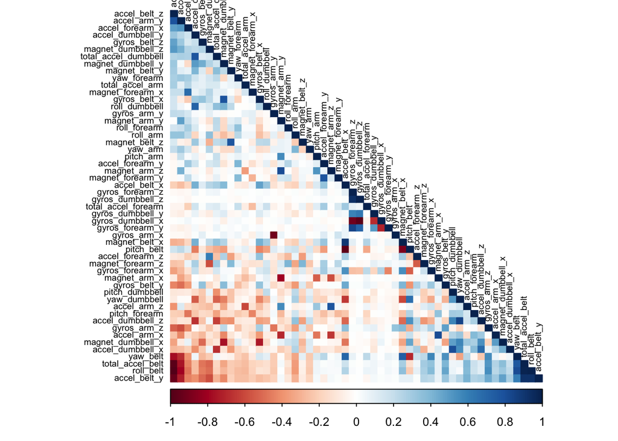

```r
# Create a Correlation Matrix
corMatrix <- cor(training[, -53])
corrplot(corMatrix, order = "FPC", method = "color", type = "lower",
         tl.cex = 0.6, tl.col = rgb(0, 0, 0))
```

Dark color denotes highly correlated variables in the matrix, and we can spot a few important ones.

## 2. Model Building + Testing

## 2.1 Decision Trees

```r
# Set up control for training to use 3-fold cross validation
control <- trainControl(method="cv", number=3, verboseIter=F)
```

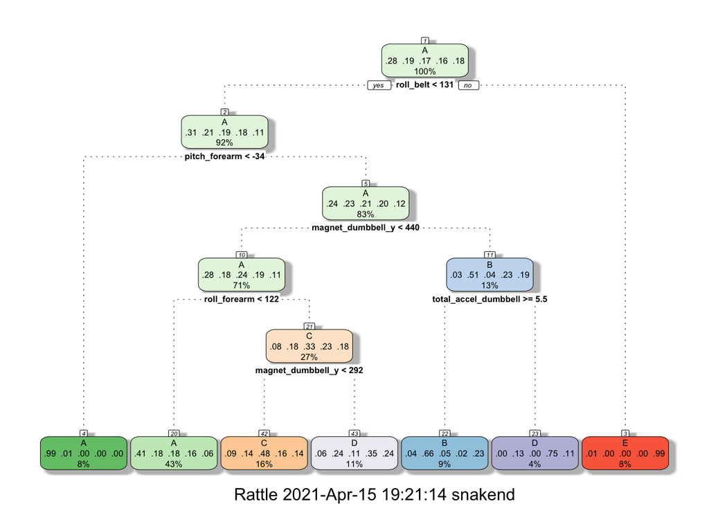

```r
# Decision Trees Model
mod_trees <- train(classe~., data=train, method="rpart", trControl = control, tuneLength = 5)
fancyRpartPlot(mod_trees$finalModel)
```

```r
# Prediction
pred_trees <- predict(mod_trees, valid)
cmtrees <- confusionMatrix(pred_trees, factor(valid$class))
cmtrees
```

```
## Confusion Matrix and Statistics
##
##           Reference
## Prediction    A    B    C    D    E
##          A 1519  473  484  451  156
##          B   28  355   45   10  130
##          C   83  117  423  131  131
##          D   40  194   74  372  176
##          E    4    0    0    0  489
##
## Overall Statistics
##
##                Accuracy : 0.5366
##                  95% CI : (0.5238, 0.5494)
##     No Information Rate : 0.2845
##     P-Value [Acc > NIR] : < 2.2e-16
##
##                   Kappa : 0.3957
##
##  Mcnemar's Test P-Value : < 2.2e-16
##
## Statistics by Class:
##
##                      Class: A Class: B Class: C Class: D Class: E
## Sensitivity            0.9074  0.31168  0.41228  0.38589  0.45194
## Specificity            0.6286  0.95512  0.90492  0.90165  0.99917
## Pos Pred Value         0.4927  0.62500  0.47797  0.43458  0.99189
## Neg Pred Value         0.9447  0.85255  0.87940  0.88228  0.89002
## Prevalence             0.2845  0.19354  0.17434  0.16381  0.18386
## Detection Rate         0.2581  0.06032  0.07188  0.06321  0.08309
## Detection Prevalence   0.5239  0.09652  0.15038  0.14545  0.08377
## Balanced Accuracy      0.7680  0.63340  0.65860  0.64377  0.72555
```

## 2.2 Support Vector Machine

```r
### SVM
mod_svm <- train(classe~., data=train, method="svmLinear", trControl = control, tuneLength = 5, verbose = F)

pred_svm <- predict(mod_svm, valid)
cmsvm <- confusionMatrix(pred_svm, factor(valid$classe))
cmsvm
```

```
## Confusion Matrix and Statistics
##
##           Reference
## Prediction    A    B    C    D    E
##          A 1537  154   79   69   50
##          B   29  806   90   46  152
##          C   40   81  797  114   69
##          D   61   22   32  697   50
##          E    7   76   28   38  761
##
## Overall Statistics
##
##                Accuracy : 0.7813
##                  95% CI : (0.7705, 0.7918)
##     No Information Rate : 0.2845
##     P-Value [Acc > NIR] : < 2.2e-16
##
##                   Kappa : 0.722
##
##  Mcnemar's Test P-Value : < 2.2e-16
##
## Statistics by Class:
##
##                      Class: A Class: B Class: C Class: D Class: E
## Sensitivity            0.9182   0.7076   0.7768   0.7230   0.7033
## Specificity            0.9164   0.9332   0.9374   0.9665   0.9690
## Pos Pred Value         0.8137   0.7177   0.7239   0.8086   0.8363
## Neg Pred Value         0.9657   0.9301   0.9521   0.9468   0.9355
## Prevalence             0.2845   0.1935   0.1743   0.1638   0.1839
## Detection Rate         0.2612   0.1370   0.1354   0.1184   0.1293
## Detection Prevalence   0.3210   0.1908   0.1871   0.1465   0.1546
## Balanced Accuracy      0.9173   0.8204   0.8571   0.8447   0.8362
```

## 2.3 Random Forest

```r
# Random Forest Model Fit
set.seed(12345)
controlRF <- trainControl(method="cv", number=3, verboseIter=FALSE)
modFitRandForest <- train(classe ~ ., data=train, method="rf",
                          trControl=controlRF)
modFitRandForest$finalModel
```

```
##
## Call:
##  randomForest(x = x, y = y, mtry = param$mtry)
##                Type of random forest: classification
##                      Number of trees: 500
## No. of variables tried at each split: 2
##
##         OOB estimate of  error rate: 0.68%
## Confusion matrix:
##      A    B    C    D    E  class.error
## A 3903    3    0    0    0 0.0007680492
## B   14 2636    8    0    0 0.0082768999
## C    0   19 2375    2    0 0.0087646077
## D    0    0   40 2210    2 0.0186500888
## E    0    0    1    5 2519 0.0023762376
```

So, we finalize by using Random Forest in order to make our prediction over the 20 different cases of the testing data:

```r
predictTEST <- predict(modFitRandForest, newdata=testing)
predictTEST
```

```
##  [1] B A B A A E D B A A B C B A E E A B B B
## Levels: A B C D E
```